# Assignment 4

Zoe Iacovino

9/24/2020

```r
library(tidyverse)
```

```r
library(ggplot2)
library(ggthemes)
library (ggmosaic)
mfa<- read.csv("2017 ACS Family Assistance Household.csv")%>%
  mutate(FERH = ifelse(FERH == "No", 0, 1))%>%
  mutate(SNAP = ifelse(SNAP == "No", 0, 1))
```

# Linear Regression

```r
model <- lm(KIDS ~ SNAP + FINC + FERH + AGE,
            data = mfa)

summary(model)
```

```
##
## Call:
## lm(formula = KIDS ~ SNAP + FINC + FERH + AGE, data = mfa)
##
## Residuals:
##     Min      1Q  Median      3Q     Max
## -2.2168 -0.4861 -0.0648  0.3559  8.1759
##
## Coefficients:
##               Estimate Std. Error t value Pr(>|t|)
## (Intercept)  3.004e+00  3.460e-02  86.830   <2e-16 ***
## SNAP         2.178e-01  2.608e-02   8.348   <2e-16 ***
## FINC         4.164e-07  1.470e-08  28.329   <2e-16 ***
## FERH        -2.549e-01  3.041e-02  -8.382   <2e-16 ***
## AGE         -5.448e-02  1.149e-03 -47.396   <2e-16 ***
## ---
## Signif. codes:  0 '***' 0.001 '**' 0.01 '*' 0.05 '.' 0.1 ' ' 1
##
## Residual standard error: 0.7196 on 7037 degrees of freedom
## Multiple R-squared:  0.298,  Adjusted R-squared:  0.2976
## F-statistic: 746.9 on 4 and 7037 DF,  p-value: < 2.2e-16
```

What we have here seems to be statistically significant finding, of very small effects on the number of children in the household. These variations on the number of related children explain about 30% of that variation.

Assuming the household is not receving SNAP, has no annual income, did not welcome a new child, and has an average age of zero (which of course makes zero sense) a household is likely to have three children. Every other variable has an effect of increasing the number of kids by less than one child. Logically, this doesn’t make much sense but is notable: neither dependence on welfare, income, having a new baby, nor the average age of the household actually change the number of kids one has.

# Logistic Regression

```r
model_log <- glm(FERH ~ SNAP + FINC + KIDS,
            data = mfa,
            family = binomial())

summary(model_log)
```

```
##
## Call:
## glm(formula = FERH ~ SNAP + FINC + KIDS, family = binomial(),
##     data = mfa)
##
## Deviance Residuals:
##     Min       1Q   Median       3Q      Max
## -0.8155  -0.4498  -0.4288  -0.4139   2.4219
##
## Coefficients:
##               Estimate Std. Error z value Pr(>|z|)
## (Intercept) -2.448e+00  9.632e-02 -25.412   <2e-16 ***
## SNAP         2.840e-01  1.144e-01   2.482   0.0131 *
## FINC        -1.704e-07  8.063e-08  -2.113   0.0346 *
## KIDS         1.240e-01  4.614e-02   2.688   0.0072 **
## ---
## Signif. codes:  0 '***' 0.001 '**' 0.01 '*' 0.05 '.' 0.1 ' ' 1
##
## (Dispersion parameter for binomial family taken to be 1)
##
##     Null deviance: 4367.5  on 7041  degrees of freedom
## Residual deviance: 4346.0  on 7038  degrees of freedom
## AIC: 4354
##
## Number of Fisher Scoring iterations: 5
```

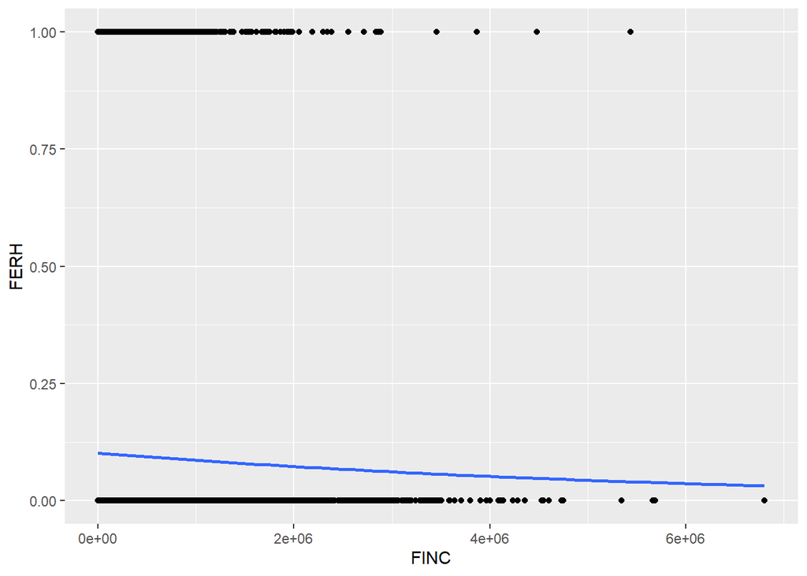

```r
ggplot(mfa, aes(x=FINC, y=FERH)) + geom_point() +
  stat_smooth(method="glm", method.args=list(family="binomial"), se=FALSE)
```

For a one unit change in SNAP (that is, receiving SNAP) the likelihood of having another child increases by a factor of .28. A $1 increase in annual income as a miniscule affect on whether someone chooses to have another child. These findings are roughly statistically significant. The number of kids, with every one increase in children in the household, there is a likelihood increase of having recently had a child by a factor of .12. These are not huge effects–which again is notable. The fact of having another child is not greatly affected by receiving food assistance, income, or the number of kids already in the household.